# ME613 - Análise de Regressão

## Critérios para Seleção de Modelos

## Introdução

Fases na construção de um modelo:

- Coleta e preparação dos dados.
- Redução do número de variáveis preditoras.
- Refinamento e seleção de modelo.
- Validação do modelo.

## Introdução

Se tivermos \(p-1\) variáveis preditoras, podemos construir \(2^{p-1}\) modelos diferentes.

Mesmo se considerarmos todos esses modelos (computacionalmente intenso), precisaríamos de algum critério para selecionar entre eles.

Métodos para seleção de modelos/variáveis foram desenvolvidos para identificar um subgrupo de variáveis que são “boas” para o modelo, segundo algum critério.

Há vários critérios desenvolvidos na literatura. Neste curso, focaremos em seis.

## \(R^2_p\)

Para o critério \(R_p^2\), a idéia é utilizar o coeficiente de determinação, \(R^2\) para identificar subgrupos das variáveis preditoras que, quando incluídas no modelo, produzem um alto valor para \(R^2\).

> \(R_p^2\) indica que temos \(p\) parâmetros no modelo, isto é, \(p-1\) variáveis preditoras incluídas no modelo.

\[R_p^2=1-\frac{SQE_p}{SQT}\]

> O objetivo deste critério não é maximização: \(R_p^2\) sempre irá aumentar conforme mais variáveis preditoras são incluídas no modelo. A idéia é comparar os diversos \(R_p^2\)’s e verificar se adicionar mais variáveis ainda traz um aumento.

## Exemplo: Cirurgias

\(Y\): tempo de sobrevivência

\(X_1\): blood clotting score

\(X_2\): índice de prognóstico

\(X_3\): teste de função enzimática

\(X_4\): teste de função do fígado

\(X_5\): idade (anos)

\(X_6\): gênero (0=masculino, 1=feminino)

\(X_7\): uso de álcool (1 = moderado, 0 = nenhum ou severo)

\(X_8\): uso de álcool (1 = severo, 0 = nenhum ou moderado)

## Exemplo

Considerando \(X_1\), \(X_2\), \(X_3\) e \(X_4\), temos \(2^4=16\) modelos possíveis.

| Variáveis no modelo | p | \(R_p^2\) | Variáveis no modelo | p | \(R_p^2\) |
| --- | --- | --- | --- | --- | --- |
| nenhuma | 1 | 0 | \(X_2\) \(X_3\) | 3 | 0.663 |
| \(X_1\) | 2 | 0.061 | \(X_2\) \(X_4\) | 3 | 0.483 |
| \(X_2\) | 2 | 0.221 | \(X_3\) \(X_4\) | 3 | 0.599 |
| \(X_3\) | 2 | 0.428 | \(X_1\) \(X_2\) \(X_3\) | 4 | 0.757 |
| \(X_4\) | 2 | 0.422 | \(X_1\) \(X_2\) \(X_4\) | 4 | 0.487 |
| \(X_1\) \(X_2\) | 3 | 0.263 | \(X_1\) \(X_3\) \(X_4\) | 4 | 0.612 |
| \(X_1\) \(X_3\) | 3 | 0.549 | \(X_2\) \(X_3\) \(X_4\) | 4 | 0.718 |
| \(X_1\) \(X_4\) | 3 | 0.43 | \(X_1\) \(X_2\) \(X_3\) \(X_4\) | 5 | 0.759 |

## Exemplo

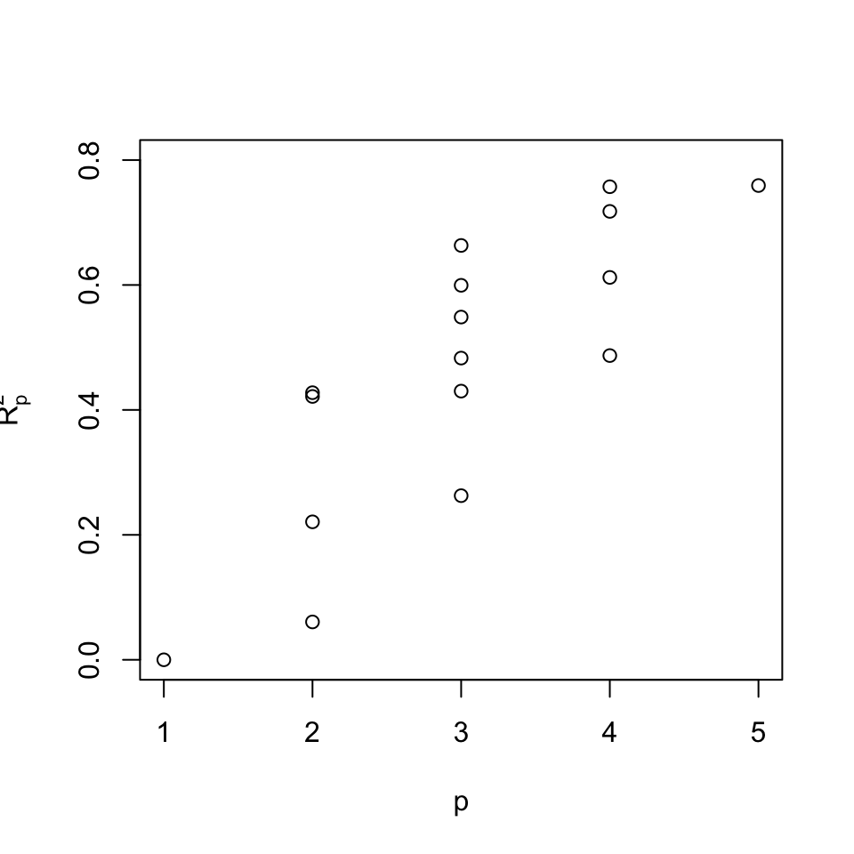

## \(R^2_{a,p}\)

Como \(R_p^2\) não leva em conta o número de parâmetros no modelo e sempre aumenta conforme temos mais variáveis incluídas, uma alternativa é usar:

\[R^2_{a,p}=1-\left(\frac{n-1}{n-p}\right)\frac{SQE_p}{SQT}=1-\frac{QME_p}{SQT/(n-1)}\]

\(R^2_{a,p}\) aumenta se e somente se \(QME_p\) diminui.

## Exemplo

| Variáveis no modelo | p | \(R_{a,p}^2\) | Variáveis no modelo | p | \(R_{a,p}^2\) |
| --- | --- | --- | --- | --- | --- |
| nenhuma | 1 | 0 | \(X_2\) \(X_3\) | 3 | 0.65 |
| \(X_1\) | 2 | 0.043 | \(X_2\) \(X_4\) | 3 | 0.463 |
| \(X_2\) | 2 | 0.206 | \(X_3\) \(X_4\) | 3 | 0.584 |
| \(X_3\) | 2 | 0.417 | \(X_1\) \(X_2\) \(X_3\) | 4 | 0.743 |
| \(X_4\) | 2 | 0.41 | \(X_1\) \(X_2\) \(X_4\) | 4 | 0.456 |
| \(X_1\) \(X_2\) | 3 | 0.234 | \(X_1\) \(X_3\) \(X_4\) | 4 | 0.589 |
| \(X_1\) \(X_3\) | 3 | 0.531 | \(X_2\) \(X_3\) \(X_4\) | 4 | 0.701 |
| \(X_1\) \(X_4\) | 3 | 0.408 | \(X_1\) \(X_2\) \(X_3\) \(X_4\) | 5 | 0.74 |

## Exemplo

[figure not shown]

## \(C_p\) de Mallow

Este critério avalia o erro quadrático médio dos \(n\) valores ajustados segundo um modelo a ser considerado.

Erro de cada valor ajustado é dado por:

\[\hat{Y}_i-\mu_i\]

em que \(\mu_i\) é o valor verdadeiro da função resposta.

Temos o viés:

\[E(\hat{Y}_i)-\mu_i\]

E um componente aleatório de erro:

\[\hat{Y}_i-E(\hat{Y}_i)\]

## \(C_p\) de Mallow

\[(\hat{Y}_i-\mu_i)^2 = [(E(\hat{Y}_i)-\mu_i) + (\hat{Y}_i-E(\hat{Y}_i))]^2\]

\[E(\hat{Y}_i-\mu_i)^2 = [E(\hat{Y}_i)-\mu_i]^2 + Var(\hat{Y}_i)\]

Erro quadrático médio total:

\[\sum_{i=1}^n[E(\hat{Y}_i)-\mu_i]^2 + \sum_{i=1}^n Var(\hat{Y}_i)\]

Medida para o critério:

\[\Gamma_p=\frac{1}{\sigma^2}\left[ \sum_{i=1}^n[E(\hat{Y}_i)-\mu_i]^2 + \sum_{i=1}^n Var(\hat{Y}_i) \right]\]

(erro quadrático médio total dividido pela verdadeira variância do erro)

## \(C_p\) de Mallow

Estamos considerando incluir \(p-1\) variáveis, mas assuma que o número ideal de variáveis a serem incluídas no modelo seja \(P-1>p-1\).

Se assumirmos que o modelo incluindo as \(P-1\) variáveis é correto, temos que \(QME(X_1,\ldots,X_{P-1})\) é um estimador não viesado para \(\sigma^2\).

Estimador para \(\Gamma_p\) é dado por:

\[C_p=\frac{SQE_p}{QME(X_1,\ldots,X_{P-1})}-(n-2p)\]

## \(C_p\) de Mallow

Se o modelo com \(p-1\) variáveis é adequado, então \(E\left[\frac{SQE_p}{(n-p)}\right]=\sigma^2\), de maneira que \(E\left[ \frac{SQE_p}{QME(X_1,\ldots,X_{P-1})}\right] = n-p\).

Portanto, se o modelo com \(p-1\) variáveis é aproximadamente adequado, esperamos que \(C_p\approx p\).

Procuramos o menor \(C_p\) tal que \(C_p\approx p\).

## Exemplo

Modelo considerando as variáveis \(X_1\), \(X_2\), \(X_3\) e \(X_4\) (\(P-1=4\))

Incluindo apenas \(X_4\) (\(p=2\)):

\[C_p=\frac{SQE(X_4)}{QME(X_1,\ldots,X_4)}-(n-2p)\]

## Exemplo

```
## Analysis of Variance Table
##
## Response: lnY
##           Df Sum Sq Mean Sq F value    Pr(>F)
## X4         1 5.3990  5.3990  37.894 1.092e-07 ***
## Residuals 52 7.4087  0.1425
## ---
## Signif. codes:  0 '***' 0.001 '**' 0.01 '*' 0.05 '.' 0.1 ' ' 1
```

```
## Analysis of Variance Table
##
## Response: lnY
##           Df Sum Sq Mean Sq  F value    Pr(>F)
## X1         1 0.7763  0.7763  12.3337 0.0009661 ***
## X2         1 2.5888  2.5888  41.1325 5.377e-08 ***
## X3         1 6.3341  6.3341 100.6408 1.810e-13 ***
## X4         1 0.0246  0.0246   0.3905 0.5349320
## Residuals 49 3.0840  0.0629
## ---
## Signif. codes:  0 '***' 0.001 '**' 0.01 '*' 0.05 '.' 0.1 ' ' 1
```

\[C_p=\frac{SQE(X_4)}{QME(X_1,\ldots,X_4)}-(n-2p)=\frac{7.4087314}{0.062938}-(54-2\times 2)= 67.7147725\]

## Exemplo

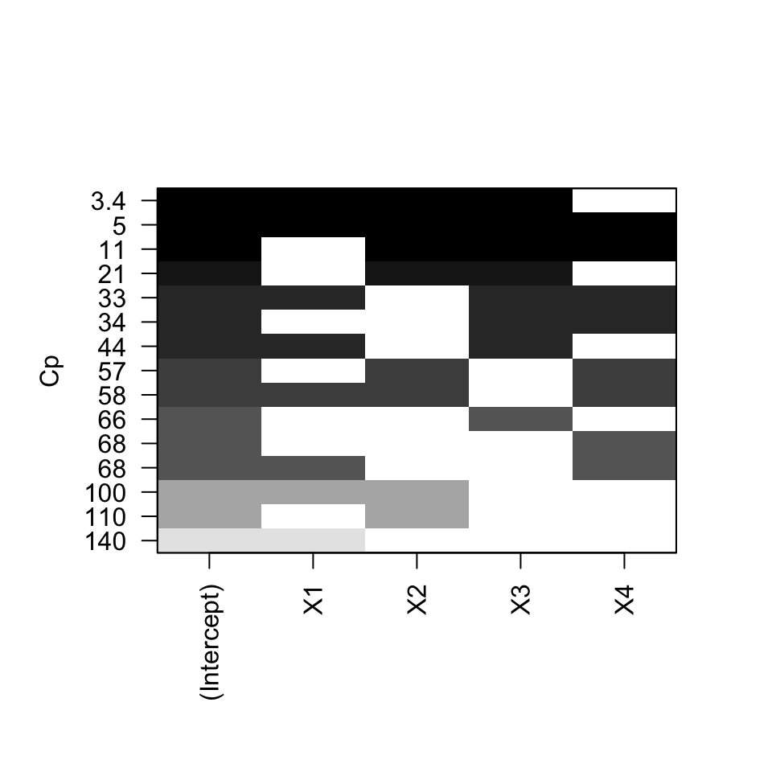

```r
library(leaps)
leaps<-regsubsets(lnY~X1+X2+X3+X4,data=dados,nbest=10)
plot(leaps,scale="Cp")
```

## \(AIC\) e \(BIC\)

Procuramos modelos com valores pequenos de \(AIC\), \(BIC\).

\(AIC\): *Akaike’s information criterion*

\[AIC_p=n \ln (SQE_p)-n\ln n +2p\]

\(BIC\): *Bayesian information criterion*

\[BIC_p=n \ln (SQE_p)-n\ln n +\ln (n) p\]

## Exemplo

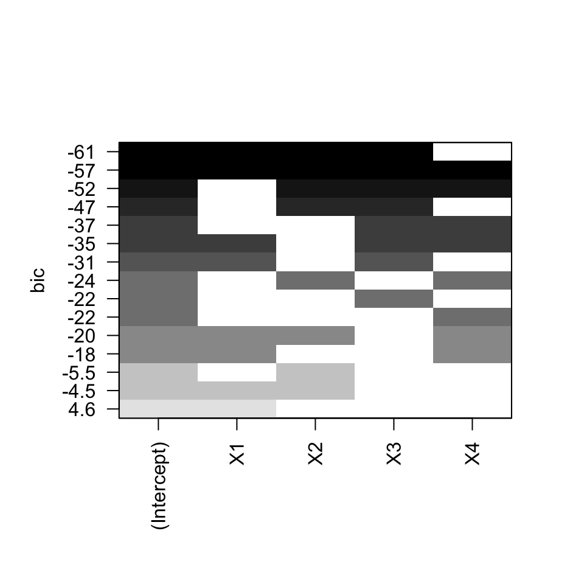

```r
plot(leaps,scale="bic")
```

## \(PRESS_p\)

\(PRESS_p\) (*prediction sum of squares*): critério para medir quão adequado é o uso dos valores ajustados obtidos a partir de um modelo com menos variáveis para predizer os valores observados de \(Y\).

\(SQE=\sum(Y_i-\hat{Y}_i)^2\) também serve para este propósito.

A diferença é que a medida \(PRESS\) é obtida após a exclusão da \(i\)-ésima observação e estimação do modelo com as \(n-1\) observações restantes, e então usar este modelo para predizer o valor de \(Y\) para a \(i\)-ésima observação.

Notação: \(\hat{Y}_{i(i)}\) indica o valor predito para a \(i\)-ésima observação quando esta foi excluída na obtenção do modelo.

## \(PRESS_p\)

\[PRESS_p=\sum_{i=1}^n(Y_i-\hat{Y}_{i(i)})^2\]

Modelos com \(PRESS_p\) pequenos são considerados bons candidatos (com erro de predição pequeno).

Seja \(d_i=Y_i-\hat{Y}_{i(i)}\), reescrevemos: \(d_i=\frac{e_i}{1-h_{ii}}\)

## Exemplo

```r
library(qpcR)
modelo1 <- lm(lnY ~ 1,data=dados)
modelo2 <- lm(lnY ~ X1,data=dados)
modelo3 <- lm(lnY ~ X2,data=dados)
modelo4 <- lm(lnY ~ X3,data=dados)
modelo5 <- lm(lnY ~ X4,data=dados)
modelo6 <- lm(lnY ~ X1+X2,data=dados)
modelo7 <- lm(lnY ~ X1+X3,data=dados)
modelo8 <- lm(lnY ~ X1+X4,data=dados)
modelo9 <- lm(lnY ~ X2+X3,data=dados)
modelo10 <- lm(lnY ~ X2+X4,data=dados)
modelo11 <- lm(lnY ~ X3+X4,data=dados)
modelo12 <- lm(lnY ~ X1+X2+X3,data=dados)
modelo13 <- lm(lnY ~ X1+X2+X4,data=dados)
modelo14 <- lm(lnY ~ X1+X3+X4,data=dados)
modelo15 <- lm(lnY ~ X2+X3+X4,data=dados)
modelo16 <- lm(lnY ~ X1+X2+X3+X4,data=dados)
PRESS(modelo1,verbose=FALSE)$stat
```

```
## [1] 13.2956
```

## Exemplo

| Variáveis no modelo | p | \(PRESS_p\) | Variáveis no modelo | p | \(PRESS_p\) |
| --- | --- | --- | --- | --- | --- |
| nenhuma | 1 | 13.296 | \(X_2\) \(X_3\) | 3 | 5.065 |
| \(X_1\) | 2 | 13.512 | \(X_2\) \(X_4\) | 3 | 7.476 |
| \(X_2\) | 2 | 10.744 | \(X_3\) \(X_4\) | 3 | 6.121 |
| \(X_3\) | 2 | 8.327 | \(X_1\) \(X_2\) \(X_3\) | 4 | 3.914 |
| \(X_4\) | 2 | 8.025 | \(X_1\) \(X_2\) \(X_4\) | 4 | 7.903 |
| \(X_1\) \(X_2\) | 3 | 11.062 | \(X_1\) \(X_3\) \(X_4\) | 4 | 6.207 |
| \(X_1\) \(X_3\) | 3 | 6.988 | \(X_2\) \(X_3\) \(X_4\) | 4 | 4.597 |
| \(X_1\) \(X_4\) | 3 | 8.472 | \(X_1\) \(X_2\) \(X_3\) \(X_4\) | 5 | 4.069 |

## Procedimentos Automáticos para Seleção de Modelos

## “Best” Subsets Algorithms

Para o exemplo visto anteriormente, se considerarmos todas as variáveis, temos \(2^8=256\) modelos possíveis.

## Exemplo - Usando \(AIC_p\)

```r
library(bestglm)
Xy = dados[,-9] # excluindo coluna do Y original, usamos ln(Y) como variável resposta
names(Xy) <- c(names(Xy)[1:8],"y")
modelos <- bestglm(Xy,IC="AIC",TopModels = 2)
modelos$Subsets
```

```
##    (Intercept)    X1    X2    X3    X4    X5    X6    X7    X8 logLikelihood
## 0         TRUE FALSE FALSE FALSE FALSE FALSE FALSE FALSE FALSE      38.85126
## 1         TRUE FALSE FALSE  TRUE FALSE FALSE FALSE FALSE FALSE      53.91343
## 2         TRUE FALSE  TRUE  TRUE FALSE FALSE FALSE FALSE FALSE      68.24165
## 3         TRUE FALSE  TRUE  TRUE FALSE FALSE FALSE FALSE  TRUE      79.49246
## 4         TRUE  TRUE  TRUE  TRUE FALSE FALSE FALSE FALSE  TRUE      86.67568
## 5         TRUE  TRUE  TRUE  TRUE FALSE FALSE  TRUE FALSE  TRUE      87.90259
## 6*        TRUE  TRUE  TRUE  TRUE FALSE  TRUE  TRUE FALSE  TRUE      88.91714
## 7         TRUE  TRUE  TRUE  TRUE FALSE  TRUE  TRUE  TRUE  TRUE      89.36782
## 8         TRUE  TRUE  TRUE  TRUE  TRUE  TRUE  TRUE  TRUE  TRUE      89.38549
##           AIC
## 0   -77.70252
## 1  -105.82686
## 2  -132.48329
## 3  -152.98493
## 4  -165.35135
## 5  -165.80517
## 6* -165.83429
## 7  -164.73565
## 8  -162.77098
```

## Exemplo - Usando \(AIC_p\)

```r
melhor <- which(modelos$Subsets$AIC==min(modelos$Subsets$AIC))
numvar <- dim(Xy)[2]-1 # total de variáveis consideradas inicialmente
varincluidas <- modelos$Subsets[melhor,2:(numvar+1)] # variaveis escolhidas segundo criterio
varincluidas
```

```
##      X1   X2   X3    X4   X5   X6    X7   X8
## 6* TRUE TRUE TRUE FALSE TRUE TRUE FALSE TRUE
```

```r
modeloescolhidoAIC <- lm(y ~ .,data=Xy[,c(which(varincluidas==TRUE),which(names(Xy)=="y"))])
summary(modeloescolhidoAIC)$coef
```

```
##                 Estimate  Std. Error   t value     Pr(>|t|)
## (Intercept)  4.053974209 0.234793506 17.266126 5.572016e-22
## X1           0.071517057 0.018637294  3.837309 3.701898e-04
## X2           0.013755482 0.001709437  8.046792 2.169036e-10
## X3           0.015116499 0.001385313 10.911972 1.777375e-14
## X5          -0.003450094 0.002571776 -1.341522 1.861972e-01
## X6           0.087316639 0.057701672  1.513243 1.369140e-01
## X8           0.350903932 0.076391406  4.593500 3.276184e-05
```

## Exemplo - Usando \(BIC_p\)

```r
modelos <- bestglm(Xy,IC="BIC")
modelos$Subsets
```

```
##    (Intercept)    X1    X2    X3    X4    X5    X6    X7    X8 logLikelihood
## 0         TRUE FALSE FALSE FALSE FALSE FALSE FALSE FALSE FALSE      38.85126
## 1         TRUE FALSE FALSE  TRUE FALSE FALSE FALSE FALSE FALSE      53.91343
## 2         TRUE FALSE  TRUE  TRUE FALSE FALSE FALSE FALSE FALSE      68.24165
## 3         TRUE FALSE  TRUE  TRUE FALSE FALSE FALSE FALSE  TRUE      79.49246
## 4*        TRUE  TRUE  TRUE  TRUE FALSE FALSE FALSE FALSE  TRUE      86.67568
## 5         TRUE  TRUE  TRUE  TRUE FALSE FALSE  TRUE FALSE  TRUE      87.90259
## 6         TRUE  TRUE  TRUE  TRUE FALSE  TRUE  TRUE FALSE  TRUE      88.91714
## 7         TRUE  TRUE  TRUE  TRUE FALSE  TRUE  TRUE  TRUE  TRUE      89.36782
## 8         TRUE  TRUE  TRUE  TRUE  TRUE  TRUE  TRUE  TRUE  TRUE      89.38549
##           BIC
## 0   -77.70252
## 1  -103.83788
## 2  -128.50532
## 3  -147.01798
## 4* -157.39542
## 5  -155.86025
## 6  -153.90039
## 7  -150.81276
## 8  -146.85911
```

## Exemplo - Usando \(BIC_p\)

```r
melhor <- which(modelos$Subsets$BIC==min(modelos$Subsets$BIC))
varincluidas <- modelos$Subsets[melhor,2:(numvar+1)] # variaveis escolhidas segundo criterio
varincluidas
```

```
##      X1   X2   X3    X4    X5    X6    X7   X8
## 4* TRUE TRUE TRUE FALSE FALSE FALSE FALSE TRUE
```

```r
modeloescolhidoBIC <- lm(y ~ .,data=Xy[,c(which(varincluidas==TRUE),which(names(Xy)=="y"))])
summary(modeloescolhidoBIC)$coef
```

```
##               Estimate  Std. Error   t value     Pr(>|t|)
## (Intercept) 3.85241856 0.192695224 19.992289 3.279284e-25
## X1          0.07332263 0.018973044  3.864569 3.273887e-04
## X2          0.01418507 0.001730632  8.196469 9.581863e-11
## X3          0.01545270 0.001395609 11.072371 6.145977e-15
## X8          0.35296762 0.077190626  4.572675 3.290701e-05
```

## Exemplo - Usando \(PRESS_p\)

```r
modelos <- bestglm(Xy,IC="LOOCV")
modelos$Subsets
```

```
##    (Intercept)    X1    X2    X3    X4    X5    X6    X7    X8 logLikelihood
## 0         TRUE FALSE FALSE FALSE FALSE FALSE FALSE FALSE FALSE      38.85126
## 1         TRUE FALSE FALSE  TRUE FALSE FALSE FALSE FALSE FALSE      53.91343
## 2         TRUE FALSE  TRUE  TRUE FALSE FALSE FALSE FALSE FALSE      68.24165
## 3         TRUE FALSE  TRUE  TRUE FALSE FALSE FALSE FALSE  TRUE      79.49246
## 4*        TRUE  TRUE  TRUE  TRUE FALSE FALSE FALSE FALSE  TRUE      86.67568
## 5         TRUE  TRUE  TRUE  TRUE FALSE FALSE  TRUE FALSE  TRUE      87.90259
## 6         TRUE  TRUE  TRUE  TRUE FALSE  TRUE  TRUE FALSE  TRUE      88.91714
## 7         TRUE  TRUE  TRUE  TRUE FALSE  TRUE  TRUE  TRUE  TRUE      89.36782
## 8         TRUE  TRUE  TRUE  TRUE  TRUE  TRUE  TRUE  TRUE  TRUE      89.38549
##         LOOCV
## 0  0.24621473
## 1  0.15419845
## 2  0.09380257
## 3  0.06424821
## 4* 0.05069947
## 5  0.05153172
## 6  0.05133936
## 7  0.05201306
## 8  0.05428207
```

## Exemplo - Usando \(PRESS_p\)

```r
melhor <- which(modelos$Subsets$LOOCV==min(modelos$Subsets$LOOCV))
varincluidas <- modelos$Subsets[melhor,2:(numvar+1)] # variaveis escolhidas segundo criterio
varincluidas
```

```
##      X1   X2   X3    X4    X5    X6    X7   X8
## 4* TRUE TRUE TRUE FALSE FALSE FALSE FALSE TRUE
```

```r
modeloescolhidoPRESS <- lm(y ~ .,data=Xy[,c(which(varincluidas==TRUE),which(names(Xy)=="y"))])
summary(modeloescolhidoPRESS)$coef
```

```
##               Estimate  Std. Error   t value     Pr(>|t|)
## (Intercept) 3.85241856 0.192695224 19.992289 3.279284e-25
## X1          0.07332263 0.018973044  3.864569 3.273887e-04
## X2          0.01418507 0.001730632  8.196469 9.581863e-11
## X3          0.01545270 0.001395609 11.072371 6.145977e-15
## X8          0.35296762 0.077190626  4.572675 3.290701e-05
```

## Exemplo - \(C_p\) de Mallow, \(R_p^2\), \(R_{a,p}^2\) e \(BIC_p\)

```r
library(leaps)
modelos <- regsubsets(y ~ .,data=Xy,nbest=2)
resultados = data.frame(cbind("p"=rowSums(summary(modelos)$which),summary(modelos)$which,
                              "Cp"=round(summary(modelos)$cp,2),
                              "R2"=round(summary(modelos)$rsq,2),
                          "R2adj"=round(summary(modelos)$adjr2,2),"BIC"=round(summary(modelos)$bic,2)))
resultados
```

```
##      p X.Intercept. X1 X2 X3 X4 X5 X6 X7 X8     Cp   R2 R2adj    BIC
## X1   2            1  0  0  1  0  0  0  0  0 117.41 0.43  0.42 -22.15
## X1.1 2            1  0  0  0  1  0  0  0  0 119.17 0.42  0.41 -21.58
## X2   3            1  0  1  1  0  0  0  0  0  50.47 0.66  0.65 -46.81
## X2.1 3            1  0  0  1  1  0  0  0  0  69.13 0.60  0.58 -37.44
## X3   4            1  0  1  1  0  0  0  0  1  18.91 0.78  0.76 -65.33
## X3.1 4            1  1  1  1  0  0  0  0  0  24.98 0.76  0.74 -60.50
## X4   5            1  1  1  1  0  0  0  0  1   5.75 0.83  0.82 -75.70
## X4.1 5            1  0  1  1  1  0  0  0  1  10.27 0.81  0.80 -71.01
## X5   6            1  1  1  1  0  0  1  0  1   5.54 0.84  0.82 -74.17
## X5.1 6            1  1  1  1  0  1  0  0  1   6.02 0.84  0.82 -73.63
## X6   7            1  1  1  1  0  1  1  0  1   5.79 0.84  0.82 -72.21
## X6.1 7            1  1  1  1  0  0  1  1  1   7.03 0.84  0.82 -70.76
## X7   8            1  1  1  1  0  1  1  1  1   7.03 0.85  0.82 -69.12
## X7.1 8            1  1  1  1  1  1  1  0  1   7.74 0.84  0.82 -68.28
## X8   9            1  1  1  1  1  1  1  1  1   9.00 0.85  0.82 -65.17
```

## Método *Stepwise*

- Método menos intensivo computacionalmente.
- Ao final, obtém-se apenas 1 modelo candidato.
- *forward*, *backward*, *both*

## *Forward Selection*

Início considerando \(P-1\) variáveis.

1- Ajuste uma regressão linear simples com cada uma das \(P-1\) variáveis. Para cada regressão, calcule a estatística \(t^*\) para testar se o coeficiente angular é 0.

\[t_k^*=\frac{\hat{\beta}_k}{\sqrt{\widehat{Var}(\hat{\beta}_k)}}\]

2- Considere a variável cujo \(|t^*|\) é o maior. Inclua esta variável caso \(|t^*|\) esteja acima de algum valor pré-determinado.

3 - Se alguma variável é incluída, por exemplo, \(X_7\) ajustam-se regressões com pares de variáveis, sendo que sempre uma delas é \(X_7\). Calcula-se \(t^*\) para a nova variável incluída e repita o passo 2 para decidir qual a segunda variável a ser incluída no modelo.

4 - Repita até considerar todas as variáveis.

## *Backward Selection*

1. Ajuste uma regressão linear múltipla com todas as \(P-1\) variáveis.
2. Teste iterativamente se uma das variáveis pode ser eliminada.

## Exemplo: *Forward Regression*

```r
completo = lm(y~.,data=Xy)
vazio = lm(y~1, data=Xy)
step(vazio, scope=list(upper=completo, lower=vazio), direction='forward', trace=TRUE)
Start:  AIC=-75.7
y ~ 1

       Df Sum of Sq     RSS      AIC
+ X3    1    5.4762  7.3316 -103.827
+ X4    1    5.3990  7.4087 -103.262
+ X2    1    2.8285  9.9792  -87.178
+ X8    1    1.7798 11.0279  -81.782
+ X1    1    0.7763 12.0315  -77.079
+ X6    1    0.6897 12.1180  -76.692
<none>              12.8077  -75.703
+ X5    1    0.2691 12.5386  -74.849
+ X7    1    0.2052 12.6025  -74.575
```

## Exemplo: *Forward Regression*

```r
Step:  AIC=-103.83
y ~ X3

       Df Sum of Sq    RSS     AIC
+ X2    1   3.01908 4.3125 -130.48
+ X4    1   2.20187 5.1297 -121.11
+ X1    1   1.55061 5.7810 -114.66
+ X8    1   1.13756 6.1940 -110.93
<none>              7.3316 -103.83
+ X6    1   0.25854 7.0730 -103.77
+ X5    1   0.23877 7.0928 -103.61
+ X7    1   0.06498 7.2666 -102.31
```

## Exemplo: *Forward Regression*

```r
Step:  AIC=-130.48
y ~ X3 + X2

       Df Sum of Sq    RSS     AIC
+ X8    1   1.46961 2.8429 -150.99
+ X1    1   1.20395 3.1085 -146.16
+ X4    1   0.69836 3.6141 -138.02
+ X7    1   0.22632 4.0862 -131.39
+ X5    1   0.16461 4.1479 -130.59
<none>              4.3125 -130.48
+ X6    1   0.08245 4.2300 -129.53
```

## Exemplo: *Forward Regression*

```r
Step:  AIC=-150.98
y ~ X3 + X2 + X8

       Df Sum of Sq    RSS     AIC
+ X1    1   0.66408 2.1788 -163.35
+ X4    1   0.46630 2.3766 -158.66
+ X6    1   0.13741 2.7055 -151.66
<none>              2.8429 -150.99
+ X5    1   0.07081 2.7721 -150.35
+ X7    1   0.02464 2.8182 -149.46
```

## Exemplo: *Forward Regression*

```r
 Step:  AIC=-163.35
y ~ X3 + X2 + X8 + X1

       Df Sum of Sq    RSS     AIC
+ X6    1  0.096791 2.0820 -163.81
<none>              2.1788 -163.35
+ X5    1  0.075876 2.1029 -163.26
+ X4    1  0.041701 2.1371 -162.40
+ X7    1  0.022944 2.1559 -161.92
```

## Exemplo: *Forward Regression*

```r
Step:  AIC=-163.81
y ~ X3 + X2 + X8 + X1 + X6

       Df Sum of Sq    RSS     AIC
+ X5    1  0.076782 2.0052 -163.83
<none>              2.0820 -163.81
+ X7    1  0.022387 2.0596 -162.39
+ X4    1  0.016399 2.0656 -162.23
```

## Exemplo: *Forward Regression*

```r
Step:  AIC=-163.83
y ~ X3 + X2 + X8 + X1 + X6 + X5

       Df Sum of Sq    RSS     AIC
<none>              2.0052 -163.83
+ X7    1  0.033193 1.9720 -162.74
+ X4    1  0.002284 2.0029 -161.90

Call:
lm(formula = y ~ X3 + X2 + X8 + X1 + X6 + X5, data = Xy)

Coefficients:
(Intercept)           X3           X2           X8           X1           X6           X5
    4.05397      0.01512      0.01376      0.35090      0.07152      0.08732     -0.00345
```

## Exemplo: *Backward Regression*

```r
completo = lm(y~.,data=Xy)
vazio = lm(y~1, data=Xy)
step(completo, scope=list(upper=completo, lower=vazio), direction='backward', trace=TRUE)

Start:  AIC=-160.77
y ~ X1 + X2 + X3 + X4 + X5 + X6 + X7 + X8

       Df Sum of Sq    RSS     AIC
- X4    1   0.00129 1.9720 -162.74
- X7    1   0.03220 2.0029 -161.90
- X5    1   0.07354 2.0443 -160.79
<none>              1.9707 -160.77
- X6    1   0.08415 2.0549 -160.51
- X1    1   0.31809 2.2888 -154.69
- X8    1   0.84573 2.8165 -143.49
- X2    1   2.09045 4.0612 -123.72
- X3    1   2.99085 4.9616 -112.91
```

## Exemplo: *Backward Regression*

```r
Step:  AIC=-162.74
y ~ X1 + X2 + X3 + X5 + X6 + X7 + X8

       Df Sum of Sq    RSS      AIC
- X7    1    0.0332 2.0052 -163.834
<none>              1.9720 -162.736
- X5    1    0.0876 2.0596 -162.389
- X6    1    0.0971 2.0691 -162.141
- X1    1    0.6267 2.5988 -149.833
- X8    1    0.8446 2.8166 -145.486
- X2    1    2.6731 4.6451 -118.471
- X3    1    5.0986 7.0706  -95.784
```

## Exemplo: *Backward Regression*

```r
Step:  AIC=-163.83
y ~ X1 + X2 + X3 + X5 + X6 + X8

       Df Sum of Sq    RSS      AIC
<none>              2.0052 -163.834
- X5    1    0.0768 2.0820 -163.805
- X6    1    0.0977 2.1029 -163.265
- X1    1    0.6282 2.6335 -151.117
- X8    1    0.9002 2.9055 -145.809
- X2    1    2.7626 4.7678 -119.064
- X3    1    5.0801 7.0853  -97.672
```

## Exemplo: *Backward Regression*

```r
Call:
lm(formula = y ~ X1 + X2 + X3 + X5 + X6 + X8, data = Xy)

Coefficients:
(Intercept)           X1           X2           X3           X5           X6           X8
    4.05397      0.07152      0.01376      0.01512     -0.00345      0.08732      0.35090
```

## Exemplo: *Forward Stepwise Regression*

```r
completo = lm(y~.,data=Xy)
vazio = lm(y~1, data=Xy)
step(vazio, scope=list(upper=completo, lower=vazio), direction='both', trace=TRUE)

Start:  AIC=-75.7
y ~ 1

       Df Sum of Sq     RSS      AIC
+ X3    1    5.4762  7.3316 -103.827
+ X4    1    5.3990  7.4087 -103.262
+ X2    1    2.8285  9.9792  -87.178
+ X8    1    1.7798 11.0279  -81.782
+ X1    1    0.7763 12.0315  -77.079
+ X6    1    0.6897 12.1180  -76.692
<none>              12.8077  -75.703
+ X5    1    0.2691 12.5386  -74.849
+ X7    1    0.2052 12.6025  -74.575
```

## Exemplo: *Forward Stepwise Regression*

```r
Step:  AIC=-103.83
y ~ X3

       Df Sum of Sq     RSS      AIC
+ X2    1    3.0191  4.3125 -130.483
+ X4    1    2.2019  5.1297 -121.113
+ X1    1    1.5506  5.7810 -114.658
+ X8    1    1.1376  6.1940 -110.932
<none>               7.3316 -103.827
+ X6    1    0.2585  7.0730 -103.765
+ X5    1    0.2388  7.0928 -103.615
+ X7    1    0.0650  7.2666 -102.308
- X3    1    5.4762 12.8077  -75.703
```

## Exemplo: *Forward Stepwise Regression*

```r
Step:  AIC=-130.48
y ~ X3 + X2

       Df Sum of Sq    RSS      AIC
+ X8    1    1.4696 2.8429 -150.985
+ X1    1    1.2040 3.1085 -146.161
+ X4    1    0.6984 3.6141 -138.023
+ X7    1    0.2263 4.0862 -131.394
+ X5    1    0.1646 4.1479 -130.585
<none>              4.3125 -130.483
+ X6    1    0.0824 4.2300 -129.526
- X2    1    3.0191 7.3316 -103.827
- X3    1    5.6667 9.9792  -87.178
```

## Exemplo: *Forward Stepwise Regression*

```r
Step:  AIC=-150.98
y ~ X3 + X2 + X8

       Df Sum of Sq    RSS      AIC
+ X1    1    0.6641 2.1788 -163.351
+ X4    1    0.4663 2.3766 -158.659
+ X6    1    0.1374 2.7055 -151.660
<none>              2.8429 -150.985
+ X5    1    0.0708 2.7721 -150.347
+ X7    1    0.0246 2.8182 -149.455
- X8    1    1.4696 4.3125 -130.483
- X2    1    3.3511 6.1940 -110.932
- X3    1    4.9456 7.7885  -98.562
```

## Exemplo: *Forward Stepwise Regression*

```r
Step:  AIC=-163.35
y ~ X3 + X2 + X8 + X1

       Df Sum of Sq    RSS      AIC
+ X6    1    0.0968 2.0820 -163.805
<none>              2.1788 -163.351
+ X5    1    0.0759 2.1029 -163.265
+ X4    1    0.0417 2.1371 -162.395
+ X7    1    0.0229 2.1559 -161.923
- X1    1    0.6641 2.8429 -150.985
- X8    1    0.9297 3.1085 -146.161
- X2    1    2.9873 5.1661 -118.731
- X3    1    5.4513 7.6301  -97.671
```

## Exemplo: *Forward Stepwise Regression*

```r
Step:  AIC=-163.81
y ~ X3 + X2 + X8 + X1 + X6

       Df Sum of Sq    RSS      AIC
+ X5    1    0.0768 2.0052 -163.834
<none>              2.0820 -163.805
- X6    1    0.0968 2.1788 -163.351
+ X7    1    0.0224 2.0596 -162.389
+ X4    1    0.0164 2.0656 -162.232
- X1    1    0.6235 2.7055 -151.660
- X8    1    0.9745 3.0565 -145.072
- X2    1    2.8268 4.9088 -119.490
- X3    1    5.0791 7.1611  -99.097
```

## Exemplo: *Forward Stepwise Regression*

```r
Step:  AIC=-163.83
y ~ X3 + X2 + X8 + X1 + X6 + X5

       Df Sum of Sq    RSS      AIC
<none>              2.0052 -163.834
- X5    1    0.0768 2.0820 -163.805
- X6    1    0.0977 2.1029 -163.265
+ X7    1    0.0332 1.9720 -162.736
+ X4    1    0.0023 2.0029 -161.896
- X1    1    0.6282 2.6335 -151.117
- X8    1    0.9002 2.9055 -145.809
- X2    1    2.7626 4.7678 -119.064
- X3    1    5.0801 7.0853  -97.672

Call:
lm(formula = y ~ X3 + X2 + X8 + X1 + X6 + X5, data = Xy)

Coefficients:
(Intercept)           X3           X2           X8           X1           X6           X5
    4.05397      0.01512      0.01376      0.35090      0.07152      0.08732     -0.00345
```

## Validação de Modelos

## Introdução

Verificar se um modelo candidato tem bom desempenho em dados independentes daqueles usados para ajuste.

- Coletar novos dados para verificar o modelo e seu poder preditivo.
- Deixar parte dos dados de fora do ajuste, para usar na validação.

## Validação Cruzada

Quando temos um grande número de observações, podemos dividir os dados em duas partes: *treinamento* e *teste*.

Com o subconjunto *treinamento* ajustamos o modelo.

Com o subconjunto *teste* verificamos o poder preditivo do modelo.

Calculamos o *mean squared prediction error*:

\[MSPR=\frac{\sum_{i=1}^{n^*}(Y_i-\hat{Y}_i)^2}{n^*}\]

em que \(Y_i\) é o valor da variável resposta da \(i\)-ésima observação do conjunto teste, \(\hat{Y}_i\) é o valor predito para a \(i\)-ésima observação do conjunto teste segundo o modelo usando o conjunto treinamento e \(n^*\) é o total de observações no conjunto teste.

## Exemplo

Temos 54 observações que não foram utilizadas na escolha do modelo para os dados sobre cirurgia. Este será o conjunto de dados *teste*.

Com os dados de *treinamento*, obtemos, usando \(PRESS_p\) e \(BIC_p\):

Modelo 1: \[\ln(Y)=\beta_0+\beta_1X_1+\beta_2X_2+\beta_3X_3+\beta_8X_8+\varepsilon\]

\[\ln(Y)=\beta_0+\beta_1X_1+\beta_2X_2+\beta_3X_3+\beta_5X_5+\beta_8X_8+\varepsilon\]

Usando \(AIC_p\) e \(R_{a,p}^2\), temos o Modelo 3:

\[\ln(Y)=\beta_0+\beta_1X_1+\beta_2X_2+\beta_3X_3+\beta_5X_5+\beta_6X_6+\beta_8X_8+\varepsilon\]

## Exemplo - Modelo 1

```r
dadosT <- read.table("./dados/CH09TA05.txt")
colnames(dadosT) <- c("X1","X2","X3","X4","X5","X6","X7","X8","Y","lnY")
modelo1 <- lm(lnY ~ X1 + X2 + X3 + X8,data=dados)
yhat <- predict(modelo1,newdata=dadosT)
MSPR <- function(yhat,yobs){
  mean((yobs-yhat)^2)
}
```

| Variável | Estimativa | Erro-Padrão |
| --- | --- | --- |
| Intercepto | 3.8524186 | 0.1926952 |
| \(X_1\) | 0.0733226 | 0.018973 |
| \(X_2\) | 0.0141851 | 0.0017306 |
| \(X_3\) | 0.0154527 | 0.0013956 |
| \(X_8\) | 0.3529676 | 0.0771906 |

\(MSE\) é 0.044 e \(MSPR\) é 0.077

## Exemplo - Modelo 2

```r
modelo2 <- lm(lnY ~ X1 + X2 + X3 + X5 + X8,data=dados)
yhat <- predict(modelo2,newdata=dadosT)
```

| Variável | Estimativa | Erro-Padrão |
| --- | --- | --- |
| Intercepto | 4.0381206 | 0.2376904 |
| \(X_1\) | 0.0736065 | 0.0188341 |
| \(X_2\) | 0.0140523 | 0.0017208 |
| \(X_3\) | 0.0154557 | 0.0013853 |
| \(X_5\) | -0.0034296 | 0.0026061 |
| \(X_8\) | 0.3412188 | 0.0771389 |

\(MSE\) é 0.044 e \(MSPR\) é 0.08

## Exemplo - Modelo 3

```r
modelo3 <- lm(lnY ~ X1 + X2 + X3 + X5 + X6 + X8,data=dados)
yhat <- predict(modelo3,newdata=dadosT)
```

| Variável | Estimativa | Erro-Padrão |
| --- | --- | --- |
| Intercepto | 4.0539742 | 0.2347935 |
| \(X_1\) | 0.0715171 | 0.0186373 |
| \(X_2\) | 0.0137555 | 0.0017094 |
| \(X_3\) | 0.0151165 | 0.0013853 |
| \(X_5\) | -0.0034501 | 0.0025718 |
| \(X_6\) | 0.0873166 | 0.0577017 |
| \(X_8\) | 0.3509039 | 0.0763914 |

\(MSE\) é 0.043 e \(MSPR\) é 0.079

## Agradecimento

- Slides criados por Samara F Kiihl / IMECC / UNICAMP

## Leitura

- Applied Linear Statistical Models: Capítulo 9.
- Faraway - [Linear Models with R](http://www.maths.bath.ac.uk/~jjf23/LMR/): Capítulo 10
- Draper & Smith - [Applied Regression Analysis](http://onlinelibrary.wiley.com/book/10.1002/9781118625590): Capítulo 15.
- Tutorial: Model Selection in R
- [`bestglm`](http://www2.uaem.mx/r-mirror/web/packages/bestglm/vignettes/bestglm.pdf)

[figure not shown]